# Part I - (Prosper Loan Data)

## by (Daisy Wambui Njung'e)

## Introduction

> Prosper Loan Dataset

## Preliminary Wrangling

```python
# import all packages and set plots to be embedded inline
import numpy as np
import pandas as pd
import matplotlib.pyplot as plt
import seaborn as sns

%matplotlib inline
```

```python
#Loading the dataset
loan_df=pd.read_csv('prosperLoanData.csv')
```

```python
#Loading the first rows
pd.set_option('display.max_columns', None)
loan_df.sample(10)
```

|  | ListingKey | ListingNumber | ListingCreationDate | CreditGrade | Term | LoanStatus | ClosedDate | BorrowerAPR | BorrowerRate | LenderYield | EstimatedEffectiveYield | EstimatedLoss | EstimatedReturn | ProsperRating (numeric) | ProsperRating (Alpha) | ProsperScore | ListingCategory (numeric) | BorrowerState | Occupation | EmploymentStatus | EmploymentStatusDuration | IsBorrowerHomeowner | CurrentlyInGroup | GroupKey | DateCreditPulled | CreditScoreRangeLower | CreditScoreRangeUpper | FirstRecordedCreditLine | CurrentCreditLines | … |
| --- | --- | --- | --- | --- | --- | --- | --- | --- | --- | --- | --- | --- | --- | --- | --- | --- | --- | --- | --- | --- | --- | --- | --- | --- | --- | --- | --- | --- | --- | --- |
| 61008 | 1CC43602001408793A61D03 | 1165014 | 36:42.7 | NaN | 60 | Current | NaN | 0.20040 | 0.1765 | 0.1665 | 0.15512 | 0.0749 | 0.08022 | 4.0 | C | 6.0 | 3 | IL | Doctor | Employed | 22.0 | True | False | NaN | 1/15/2014 12:56 | 680.0 | 699.0 | 6/21/1993 0:00 | 17.0 | … |
| 37611 | 3AC13461931138838398498 | 423022 | 13:54.2 | NaN | 36 | Completed | 11/25/2009 0:00 | 0.22287 | 0.2005 | 0.1905 | 0.12410 | 0.0620 | 0.12410 | 4.0 | C | 5.0 | 3 | CO | Professional | Full-time | 6.0 | True | False | NaN | 9/4/2009 14:55 | 800.0 | 819.0 | 8/25/1993 0:00 | 16.0 | … |
| 81868 | D9343593824216654BF1BCE | 989897 | 54:57.8 | NaN | 36 | Current | NaN | 0.15833 | 0.1299 | 0.1199 | 0.11477 | 0.0399 | 0.07487 | 6.0 | A | 4.0 | 1 | AZ | Teacher | Employed | 87.0 | True | False | NaN | 11/2/2013 19:55 | 720.0 | 739.0 | 2/17/1988 0:00 | 16.0 | … |
| 17645 | 6BE0356668084259110F51D | 689828 | 17:36.1 | NaN | 12 | Completed | 1/8/2013 0:00 | 0.22352 | 0.1458 | 0.1358 | 0.12660 | 0.0724 | 0.05420 | 4.0 | C | 5.0 | 2 | FL | Military Officer | Employed | 71.0 | True | False | NaN | 12/26/2012 19:17 | 660.0 | 679.0 | 1/30/2006 0:00 | 18.0 | … |
| 86973 | EDBC359461926097073A7C4 | 1011563 | 10:33.7 | NaN | 36 | Current | NaN | 0.28544 | 0.2469 | 0.2369 | 0.21650 | 0.1175 | 0.09900 | 3.0 | D | 4.0 | 7 | GA | Teacher | Employed | 99.0 | False | False | NaN | 11/11/2013 16:10 | 640.0 | 659.0 | 7/30/2008 0:00 | 5.0 | … |
| 108918 | ABF93379858573919E5A0C4 | 93709 | 43:56.9 | E | 36 | Chargedoff | 12/16/2008 0:00 | 0.23447 | 0.2270 | 0.1920 | NaN | NaN | NaN | NaN | NaN | NaN | 0 | CA | Medical Technician | Not available | NaN | False | True | 783C3371218786870A73D20 | 39:34.9 | 540.0 | 559.0 | 11/9/1998 0:00 | NaN | … |
| 77593 | 1A943389125056892ADFF33 | 139825 | 31:16.8 | C | 36 | Chargedoff | 3/3/2009 0:00 | 0.17973 | 0.1725 | 0.1625 | NaN | NaN | NaN | NaN | NaN | NaN | 0 | CA | Principal | Self-employed | 54.0 | False | True | CD0E3364909037313F32874 | 42:55.1 | 640.0 | 659.0 | 8/23/1995 0:00 | 9.0 | … |
| 651 | 00F23421117367118813432 | 338370 | 07:46.3 | B | 36 | Completed | 6/3/2011 0:00 | 0.18454 | 0.1700 | 0.1600 | NaN | NaN | NaN | NaN | NaN | NaN | 1 | NJ | Professional | Full-time | 15.0 | True | False | NaN | 19:14.2 | 680.0 | 699.0 | 10/13/1993 0:00 | 11.0 | … |
| 41293 | 67E135900910358021E177F | 906088 | 40:03.8 | NaN | 60 | Current | NaN | 0.15271 | 0.1299 | 0.1199 | 0.11477 | 0.0399 | 0.07487 | 6.0 | A | 8.0 | 1 | NH | Other | Employed | 110.0 | False | False | NaN | 9/18/2013 0:40 | 780.0 | 799.0 | 10/24/1988 0:00 | 16.0 | … |
| 37182 | 5707336780365865629AC38 | 36610 | 36:48.5 | D | 36 | Completed | 9/12/2009 0:00 | 0.16802 | 0.1500 | 0.1450 | NaN | NaN | NaN | NaN | NaN | NaN | 0 | NY | Teacher | Not available | NaN | False | False | NaN | 03:47.4 | 620.0 | 639.0 | 10/1/1990 0:00 | NaN | … |

```python
#To get the shape of the dataset
loan_df.shape
```

```
(113937, 81)
```

```python
#To see the columns in the dataset
loan_df.columns
```

```
Index(['ListingKey', 'ListingNumber', 'ListingCreationDate', 'CreditGrade',
       'Term', 'LoanStatus', 'ClosedDate', 'BorrowerAPR', 'BorrowerRate',
       'LenderYield', 'EstimatedEffectiveYield', 'EstimatedLoss',
       'EstimatedReturn', 'ProsperRating (numeric)', 'ProsperRating (Alpha)',
       'ProsperScore', 'ListingCategory (numeric)', 'BorrowerState',
       'Occupation', 'EmploymentStatus', 'EmploymentStatusDuration',
       'IsBorrowerHomeowner', 'CurrentlyInGroup', 'GroupKey',
       'DateCreditPulled', 'CreditScoreRangeLower', 'CreditScoreRangeUpper',
       'FirstRecordedCreditLine', 'CurrentCreditLines', 'OpenCreditLines',
       'TotalCreditLinespast7years', 'OpenRevolvingAccounts',
       'OpenRevolvingMonthlyPayment', 'InquiriesLast6Months', 'TotalInquiries',
       'CurrentDelinquencies', 'AmountDelinquent', 'DelinquenciesLast7Years',
       'PublicRecordsLast10Years', 'PublicRecordsLast12Months',
       'RevolvingCreditBalance', 'BankcardUtilization',
       'AvailableBankcardCredit', 'TotalTrades',
       'TradesNeverDelinquent (percentage)', 'TradesOpenedLast6Months',
       'DebtToIncomeRatio', 'IncomeRange', 'IncomeVerifiable',
       'StatedMonthlyIncome', 'LoanKey', 'TotalProsperLoans',
       'TotalProsperPaymentsBilled', 'OnTimeProsperPayments',
       'ProsperPaymentsLessThanOneMonthLate',
       'ProsperPaymentsOneMonthPlusLate', 'ProsperPrincipalBorrowed',
       'ProsperPrincipalOutstanding', 'ScorexChangeAtTimeOfListing',
       'LoanCurrentDaysDelinquent', 'LoanFirstDefaultedCycleNumber',
       'LoanMonthsSinceOrigination', 'LoanNumber', 'LoanOriginalAmount',
       'LoanOriginationDate', 'LoanOriginationQuarter', 'MemberKey',
       'MonthlyLoanPayment', 'LP_CustomerPayments',
       'LP_CustomerPrincipalPayments', 'LP_InterestandFees', 'LP_ServiceFees',
       'LP_CollectionFees', 'LP_GrossPrincipalLoss', 'LP_NetPrincipalLoss',
       'LP_NonPrincipalRecoverypayments', 'PercentFunded', 'Recommendations',
       'InvestmentFromFriendsCount', 'InvestmentFromFriendsAmount',
       'Investors'],
      dtype='object')
```

```python
loan_df.info()
```

```
<class 'pandas.core.frame.DataFrame'>
RangeIndex: 113937 entries, 0 to 113936
Data columns (total 81 columns):
ListingKey                             113937 non-null object
ListingNumber                          113937 non-null int64
ListingCreationDate                    113937 non-null object
CreditGrade                            28953 non-null object
Term                                   113937 non-null int64
LoanStatus                             113937 non-null object
ClosedDate                             55089 non-null object
BorrowerAPR                            113912 non-null float64
BorrowerRate                           113937 non-null float64
LenderYield                            113937 non-null float64
EstimatedEffectiveYield                84853 non-null float64
EstimatedLoss                          84853 non-null float64
EstimatedReturn                        84853 non-null float64
ProsperRating (numeric)                84853 non-null float64
ProsperRating (Alpha)                  84853 non-null object
ProsperScore                           84853 non-null float64
ListingCategory (numeric)              113937 non-null int64
BorrowerState                          108422 non-null object
Occupation                             110349 non-null object
EmploymentStatus                       111682 non-null object
EmploymentStatusDuration               106312 non-null float64
IsBorrowerHomeowner                    113937 non-null bool
CurrentlyInGroup                       113937 non-null bool
GroupKey                               13341 non-null object
DateCreditPulled                       113937 non-null object
CreditScoreRangeLower                  113346 non-null float64
CreditScoreRangeUpper                  113346 non-null float64
FirstRecordedCreditLine                113240 non-null object
CurrentCreditLines                     106333 non-null float64
OpenCreditLines                        106333 non-null float64
TotalCreditLinespast7years             113240 non-null float64
OpenRevolvingAccounts                  113937 non-null int64
OpenRevolvingMonthlyPayment            113937 non-null int64
InquiriesLast6Months                   113240 non-null float64
TotalInquiries                         112778 non-null float64
CurrentDelinquencies                   113240 non-null float64
AmountDelinquent                       106315 non-null float64
```

[output cut: 31 more lines]

```
LP_CustomerPayments                    113937 non-null float64
LP_CustomerPrincipalPayments           113937 non-null float64
LP_InterestandFees                     113937 non-null float64
LP_ServiceFees                         113937 non-null float64
LP_CollectionFees                      113937 non-null float64
LP_GrossPrincipalLoss                  113937 non-null float64
LP_NetPrincipalLoss                    113937 non-null float64
LP_NonPrincipalRecoverypayments        113937 non-null float64
PercentFunded                          113937 non-null float64
Recommendations                        113937 non-null int64
InvestmentFromFriendsCount             113937 non-null int64
InvestmentFromFriendsAmount            113937 non-null float64
Investors                              113937 non-null int64
dtypes: bool(3), float64(49), int64(12), object(17)
memory usage: 68.1+ MB
```

```python
#Counting the loan status
status=loan_df['LoanStatus'].value_counts()
status
```

```
Current                   56576
Completed                 38074
Chargedoff                11992
Defaulted                  5018
Past Due (1-15 days)        806
Past Due (31-60 days)       363
Past Due (61-90 days)       313
Past Due (91-120 days)      304
Past Due (16-30 days)       265
FinalPaymentInProgress      205
Past Due (>120 days)         16
Cancelled                     5
Name: LoanStatus, dtype: int64
```

```python
loan_df['EmploymentStatus'].value_counts()
```

```
Employed         67322
Full-time        26355
Self-employed     6134
Not available     5347
Other             3806
Part-time         1088
Not employed       835
Retired            795
Name: EmploymentStatus, dtype: int64
```

```python
#Getting the statistics
loan_df.describe()
```

|  | ListingNumber | Term | BorrowerAPR | BorrowerRate | LenderYield | EstimatedEffectiveYield | EstimatedLoss | EstimatedReturn | ProsperRating (numeric) | ProsperScore | ListingCategory (numeric) | EmploymentStatusDuration | CreditScoreRangeLower | CreditScoreRangeUpper | CurrentCreditLines | OpenCreditLines | TotalCreditLinespast7years | OpenRevolvingAccounts | OpenRevolvingMonthlyPayment | InquiriesLast6Months | TotalInquiries | CurrentDelinquencies | AmountDelinquent | DelinquenciesLast7Years | PublicRecordsLast10Years | PublicRecordsLast12Months | RevolvingCreditBalance | BankcardUtilization | AvailableBankcardCredit | … |
| --- | --- | --- | --- | --- | --- | --- | --- | --- | --- | --- | --- | --- | --- | --- | --- | --- | --- | --- | --- | --- | --- | --- | --- | --- | --- | --- | --- | --- | --- | --- |
| count | 1.139370e+05 | 113937.000000 | 113912.000000 | 113937.000000 | 113937.000000 | 84853.000000 | 84853.000000 | 84853.000000 | 84853.000000 | 84853.000000 | 113937.000000 | 106312.000000 | 113346.000000 | 113346.000000 | 106333.000000 | 106333.000000 | 113240.000000 | 113937.00000 | 113937.000000 | 113240.000000 | 112778.000000 | 113240.000000 | 106315.000000 | 112947.000000 | 113240.000000 | 106333.000000 | 1.063330e+05 | 106333.000000 | 106393.000000 | … |
| mean | 6.278857e+05 | 40.830248 | 0.218828 | 0.192764 | 0.182701 | 0.168661 | 0.080306 | 0.096068 | 4.072243 | 5.950067 | 2.774209 | 96.071582 | 685.567731 | 704.567731 | 10.317192 | 9.260164 | 26.754539 | 6.96979 | 398.292161 | 1.435085 | 5.584405 | 0.592052 | 984.507059 | 4.154984 | 0.312646 | 0.015094 | 1.759871e+04 | 0.561309 | 11210.225447 | … |
| std | 3.280762e+05 | 10.436212 | 0.080364 | 0.074818 | 0.074516 | 0.068467 | 0.046764 | 0.030403 | 1.673227 | 2.376501 | 3.996797 | 94.480605 | 66.458275 | 66.458275 | 5.457866 | 5.022644 | 13.637871 | 4.63097 | 447.159711 | 2.437507 | 6.429946 | 1.978707 | 7158.270157 | 10.160216 | 0.727868 | 0.154092 | 3.293640e+04 | 0.317918 | 19818.361309 | … |
| min | 4.000000e+00 | 12.000000 | 0.006530 | 0.000000 | -0.010000 | -0.182700 | 0.004900 | -0.182700 | 1.000000 | 1.000000 | 0.000000 | 0.000000 | 0.000000 | 19.000000 | 0.000000 | 0.000000 | 2.000000 | 0.00000 | 0.000000 | 0.000000 | 0.000000 | 0.000000 | 0.000000 | 0.000000 | 0.000000 | 0.000000 | 0.000000e+00 | 0.000000 | 0.000000 | … |
| 25% | 4.009190e+05 | 36.000000 | 0.156290 | 0.134000 | 0.124200 | 0.115670 | 0.042400 | 0.074080 | 3.000000 | 4.000000 | 1.000000 | 26.000000 | 660.000000 | 679.000000 | 7.000000 | 6.000000 | 17.000000 | 4.00000 | 114.000000 | 0.000000 | 2.000000 | 0.000000 | 0.000000 | 0.000000 | 0.000000 | 0.000000 | 3.121000e+03 | 0.310000 | 880.000000 | … |
| 50% | 6.005540e+05 | 36.000000 | 0.209760 | 0.184000 | 0.173000 | 0.161500 | 0.072400 | 0.091700 | 4.000000 | 6.000000 | 1.000000 | 67.000000 | 680.000000 | 699.000000 | 10.000000 | 9.000000 | 25.000000 | 6.00000 | 271.000000 | 1.000000 | 4.000000 | 0.000000 | 0.000000 | 0.000000 | 0.000000 | 0.000000 | 8.549000e+03 | 0.600000 | 4100.000000 | … |
| 75% | 8.926340e+05 | 36.000000 | 0.283810 | 0.250000 | 0.240000 | 0.224300 | 0.112000 | 0.116600 | 5.000000 | 8.000000 | 3.000000 | 137.000000 | 720.000000 | 739.000000 | 13.000000 | 12.000000 | 35.000000 | 9.00000 | 525.000000 | 2.000000 | 7.000000 | 0.000000 | 0.000000 | 3.000000 | 0.000000 | 0.000000 | 1.952100e+04 | 0.840000 | 13180.000000 | … |
| max | 1.255725e+06 | 60.000000 | 0.512290 | 0.497500 | 0.492500 | 0.319900 | 0.366000 | 0.283700 | 7.000000 | 11.000000 | 20.000000 | 755.000000 | 880.000000 | 899.000000 | 59.000000 | 54.000000 | 136.000000 | 51.00000 | 14985.000000 | 105.000000 | 379.000000 | 83.000000 | 463881.000000 | 99.000000 | 38.000000 | 20.000000 | 1.435667e+06 | 5.950000 | 646285.000000 | … |

### What is the structure of your dataset?

> ProsperLoanDataset has 81 columns and 113937 rows in total.  
> Most variables are numeric.

### What is/are the main feature(s) of interest in your dataset?

> I'm most interested in finding out if EmploymentStatus,LoanStatus,CurrentlyInGroup and other factors affect EstimatedReturn,EstimatedLoss,LenderYield,BorrowerAPR.

### What features in the dataset do you think will help support your investigation into your feature(s) of interest?

> I think the factors such as EmploymentStatus,LoanStatus will affect the LendersYield,BorrowerAPR etc.

## Univariate Exploration

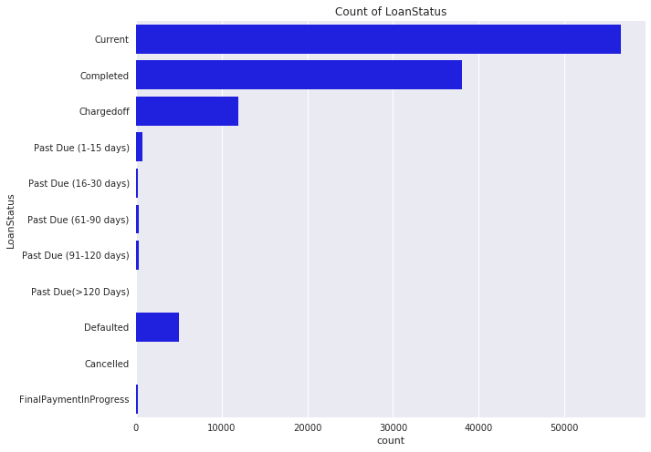

```python
#Count of loanstatus
loanstatus_ordered = ["Current", "Completed", "Chargedoff", "Past Due (1-15 days)", "Past Due (16-30 days)", "Past Due (61-90 days)","Past Due (91-120 days)","Past Due(>120 Days)","Defaulted","Cancelled","FinalPaymentInProgress"]
plt.figure(figsize=[10,8])
sns.set(style='darkgrid')
sns.countplot(data=loan_df,y='LoanStatus',color='blue',order=loanstatus_ordered)
plt.title('Count of LoanStatus');
```

> According to the plot,the most common loan status is current,then completed.Very few have passed due(>120 days) or cancelled.

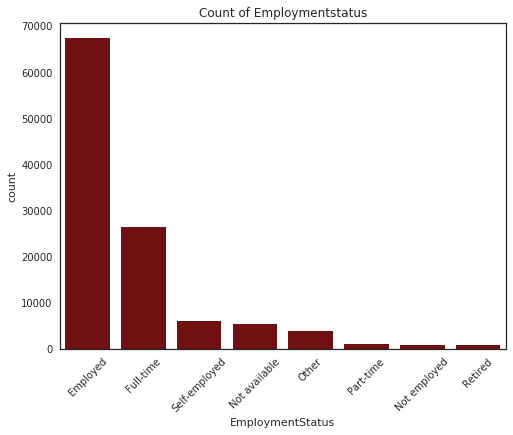

```python
#Using countplot to seee how employmentstatus is distributed
plt.figure(figsize=[8,6])
sns.set(style='white')
sns.countplot(data=loan_df,x='EmploymentStatus',color='maroon',order=loan_df['EmploymentStatus'].value_counts().index)
plt.xticks(rotation=45)
plt.title('Count of Employmentstatus');
```

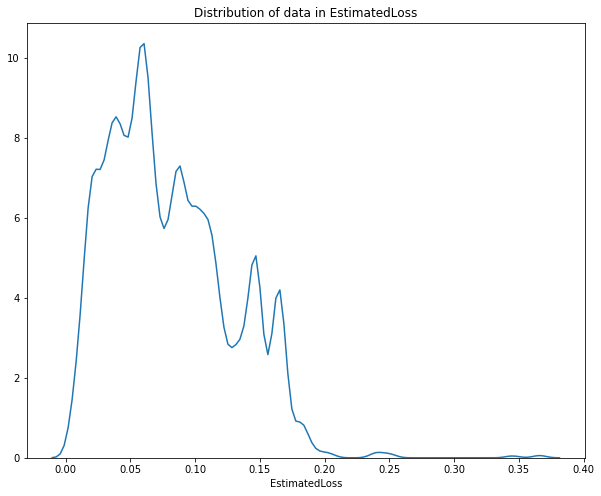

```python
#Using distplot to see the distribution of data in EstimatedLoss
plt.figure(figsize=[10,8])
sns.distplot(loan_df['EstimatedLoss'],hist=False)
plt.title('Distribution of data in EstimatedLoss');
```

> Estimatedloss is not normally distributed.

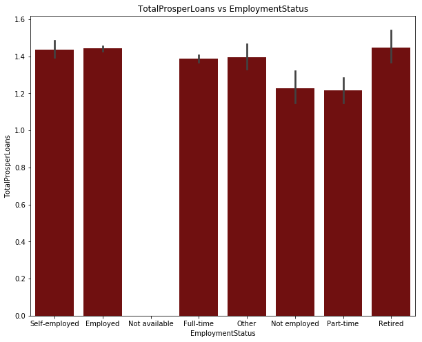

```python
#using distplot to see distribution of TotalProsperLoans
plt.figure(figsize=[10,8])
#total=loan_df['TotalProsperLoans'].dropna()
#sns.distplot(total)
sns.barplot(x='EmploymentStatus',y='TotalProsperLoans',data=loan_df,color='maroon')
plt.title('TotalProsperLoans vs EmploymentStatus');
```

> According to the listing,Retired people had higher TotalProsperLoans,while not employed and part time had a lower count of TotalProsper loans.

```
True     57478
False    56459
Name: IsBorrowerHomeowner, dtype: int64
```

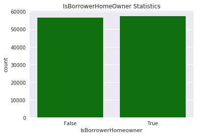

```python
#Plotting to see if borrowers are mostly homeowners or not
sns.countplot(loan_df['IsBorrowerHomeowner'],color='green')
print(loan_df['IsBorrowerHomeowner'].value_counts())
plt.title('IsBorrowerHomeOwner Statistics');
```

> Being a home owner does not affect borrowing of loans

```
False    101218
True      12719
Name: CurrentlyInGroup, dtype: int64
```

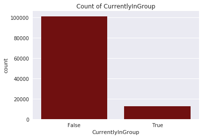

```python
#Plotting to see if borrowers are in groups
sns.countplot(loan_df['CurrentlyInGroup'],color='maroon')
print(loan_df['CurrentlyInGroup'].value_counts())
plt.title('Count of CurrentlyInGroup');
```

> Most loan borrowers are currently not in groups

### Discuss the distribution(s) of your variable(s) of interest. Were there any unusual points? Did you need to perform any transformations?

> My aim was to know factors which most borrowers have,and according to the visualizations,most loan borrowers are employed, not currently in groups.I didn't perfom any transformations when visualizing.

Of the features you investigated, were there any unusual distributions? Did you perform any operations on the data to tidy, adjust, or change the form of the data? If so, why did you do this?¶

> I didn't encounter unusual distributions,though some people had high totalprosperloans and still got loans.The variables I used didn't need adjustments but some variables I had to drop NaN values for the graphs tobe visualized.

## Bivariate Exploration

> In this section, investigate relationships between pairs of variables in your data. Make sure the variables that you cover here have been introduced in some fashion in the previous section (univariate exploration).

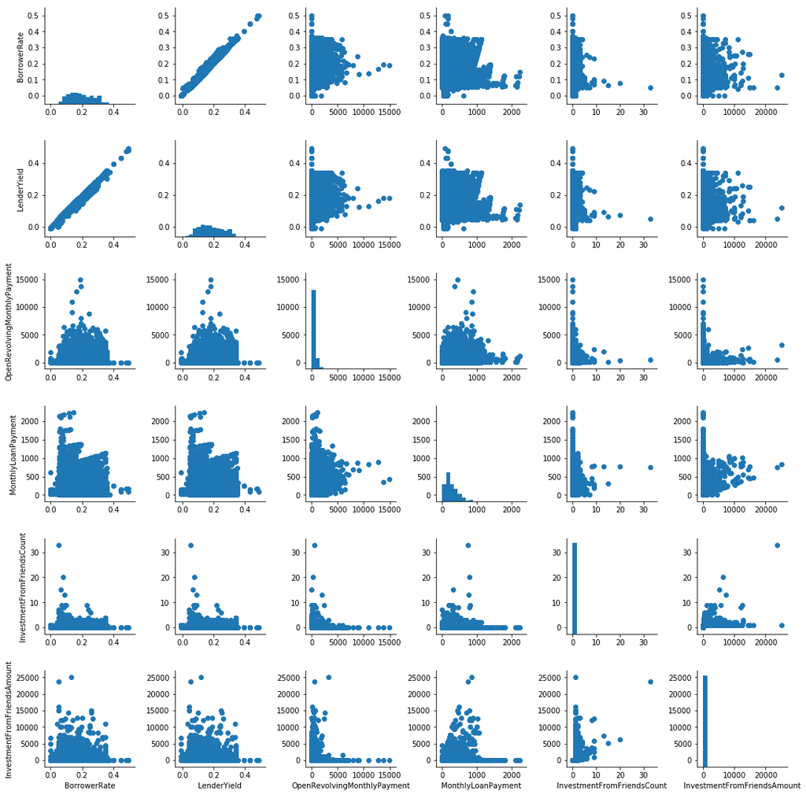

```python
#Using a pairgrid to see relationships between different variables
cols_to_plot=loan_df[['BorrowerRate','LenderYield','OpenRevolvingMonthlyPayment','MonthlyLoanPayment','InvestmentFromFriendsCount','InvestmentFromFriendsAmount']]
cols_to_plot.dropna()
numeric_vars=['BorrowerRate','LenderYield','OpenRevolvingMonthlyPayment','MonthlyLoanPayment','InvestmentFromFriendsCount','InvestmentFromFriendsAmount']

plt.figure()
g = sns.PairGrid(data = cols_to_plot, vars = numeric_vars)
g = g.map_diag(plt.hist, bins = 20);
g.map_offdiag(plt.scatter);
```

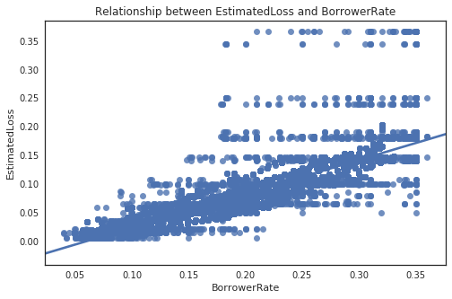

```python
#Relationship between EstimatedLoss and BorrowerRate
def regplot(x, y, **kwargs):
    #Creating a regplot with seaborn##
    default_color = sb.color_palette()[0]
    sns.scatterplot(x, y, color = default_color)
plt.figure(figsize=(8,5))
sns.regplot(data=loan_df, x=loan_df['BorrowerRate'],y=loan_df['EstimatedLoss'])
plt.title('Relationship between EstimatedLoss and BorrowerRate');
```

> The higher the Borrower rate the higher the Estimatedloss

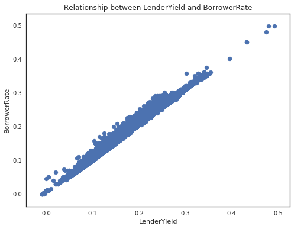

```python
#Relationship between LenderYield and BorrowerRate
plt.figure(figsize = [8, 6])
sns.set(style='white')
plt.scatter(data = loan_df, x = 'LenderYield', y = 'BorrowerRate')
plt.xlabel('LenderYield')
plt.ylabel('BorrowerRate')
plt.title('Relationship between LenderYield and BorrowerRate');
```

> The Borrowerrate and Lenderyield have a high positive correlation as per the visualization.

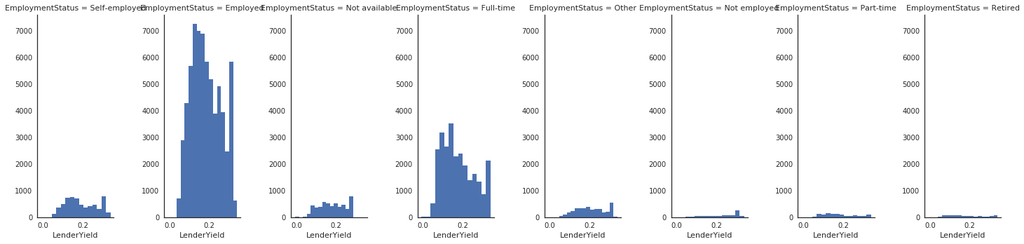

```python
g=sns.FacetGrid(data=loan_df,col='EmploymentStatus',col_wrap=None)
g.fig.set_size_inches(20, 5)
g.map(plt.hist,'LenderYield',bins=15);
```

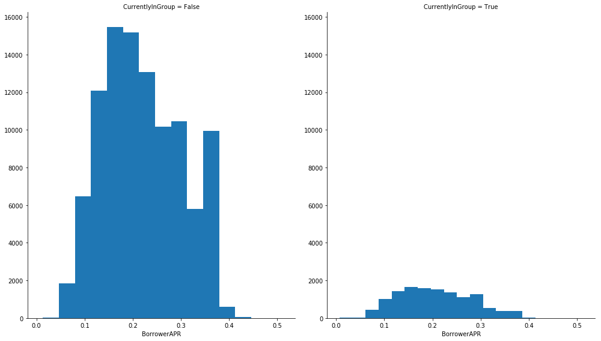

```python
#Investigating if CurrentlyInGroup affects BorrowerAPR

g=sns.FacetGrid(data=loan_df,col='CurrentlyInGroup')
g.fig.set_size_inches(14, 8)
g.map(plt.hist,'BorrowerAPR',bins=15)
```

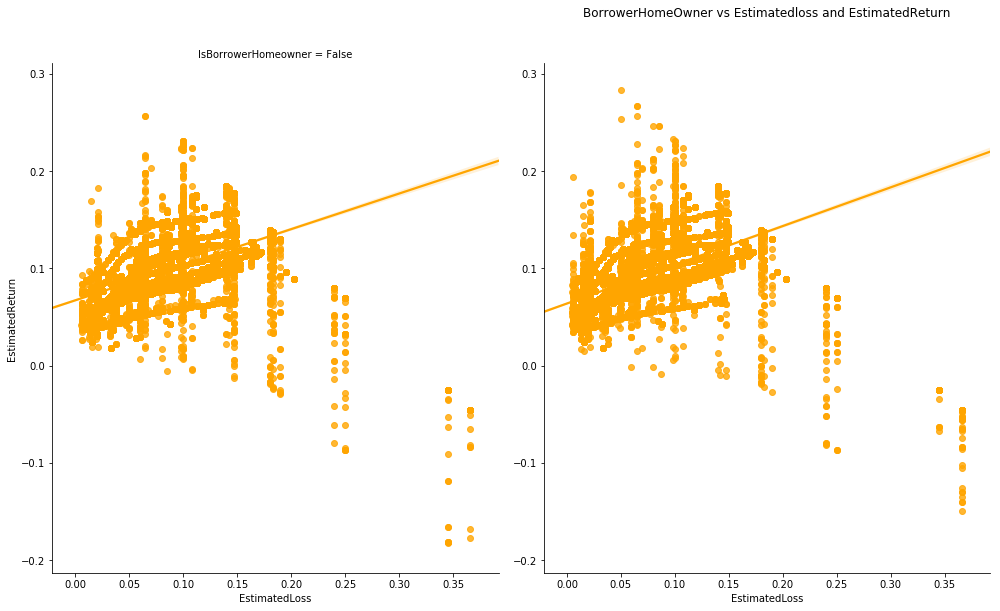

```python
g=sns.FacetGrid(data=loan_df,col='IsBorrowerHomeowner')
g.fig.set_size_inches(14, 8)
g.map(sns.regplot,'EstimatedLoss','EstimatedReturn',color='orange')
plt.title('BorrowerHomeOwner vs Estimatedloss and EstimatedReturn',y=1.08);
```

## Multivariate Exploration

> Create plots of three or more variables to investigate your data even further. Make sure that your investigations are justified, and follow from your work in the previous sections.

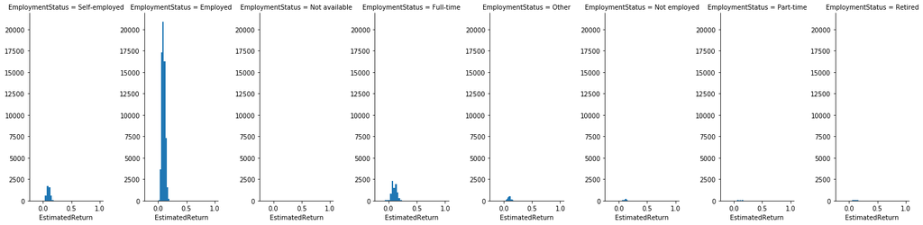

```python
#Relationship between different employmentstatus and estimated return
g=sns.FacetGrid(data=loan_df,col='EmploymentStatus',col_wrap=None)
g.fig.set_size_inches(20, 5)
g.map(plt.hist,'EstimatedReturn',bins=15)
```

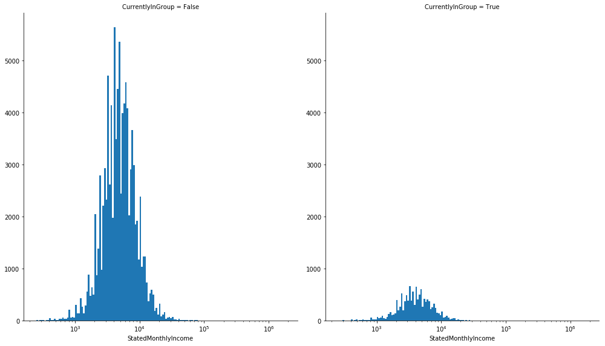

```python
g=sns.FacetGrid(data=loan_df,col='CurrentlyInGroup',size=3)
g.fig.set_size_inches(14, 8)

log_binsize = 0.025
bins = 10 ** np.arange(2.4, np.log10(loan_df['StatedMonthlyIncome'].max())+log_binsize, log_binsize)


g.map(plt.hist,'StatedMonthlyIncome',bins=bins)
plt.xscale('log')
```

[figure not shown]

```python
cols=loan_df[['EstimatedReturn','LenderYield','BorrowerAPR','MonthlyLoanPayment']]
cols.dropna()
numeric_vars=['EstimatedReturn','LenderYield','BorrowerAPR','MonthlyLoanPayment']
g = sns.PairGrid(data = cols,vars=numeric_vars)
g=g.map_diag(sns.kdeplot,shade=True)
g = g.map_upper(plt.scatter,marker="+")
g = g.map_lower(sns.kdeplot,shade=True)
```

### Were there any interesting or surprising interactions between features?

> IsBorrowerHomeOwner or not does not affect estimated return or loss